# The Halloween Candy Showdown

Andrew Bates

10/31/2018

### Welcome

Welcome to the Halloween Candy Showdown! In this workshop, we will be analyzing data on Halloween candy to determine what factors influence the popularity of a candy. Along the way, we will be learning a bit about R, RStudio, and R Markdown. Most of what we will learn about RStudio and R Markdown will be spoken, so I encourage you to make notes as we go along.

The first two sections won’t be terribly exciting. We will go over these quickly and you can just run the code without reading much of the text. Actually, you can just ignore the text because I will be explaining everything. I put the text there so you can reference it later. If I just gave you the code, you would probably forget how everything works the next time you look at it.

The necessary files are located at [my GitHub](https://github.com/asbates/ssa_r_workshops) repository (folder) for SSA workshops. The data is based on an experiment done by [FiveThirtyEight](https://fivethirtyeight.com/features/the-ultimate-halloween-candy-power-ranking/). I obtained the data from the Kaggle Datasets page [here](https://www.kaggle.com/fivethirtyeight/the-ultimate-halloween-candy-power-ranking/home).

### What’s with This Rstudio & R Markdown Business?

RStudio is an integrated development environment (IDE) for R. It provides a lot of useful features that make your R programming life easier. For example, in RStudio you have four different sections: a place for your code files, a place for the R console, a place for files/plots/packages/help, and a place for your environment (what data, variables, functions you have defined) all in one window. This keeps your work space cleaner and more organized than if you were just using R. There are a ton of other features as well, some of which we will cover in this workshop.

R Markdown is a tool that allows you to seamlessly mix your text and analysis in a single document. This makes it easier to report your analysis, allows for better reproducibility, and makes your grader’s life easier (which benefits you in turn). With R Markdown you can produce html, pdf (need LaTeX), and Word documents, html, pdf, and PowerPoint presentations, and even websites. Moreover, changing from say, a pdf to a Word document can be done with a single line of code!

Additionally, RStudio and R Markdown work even better when used together. RStudio provides tools that handle the back end of R Markdown, simplifying the process.

### Load the Data

To load the data, we will be using two R packages. A package is a collection of R code that solves a particular problem. Basically, somebody wants to solve a new problem or improve the existing way of doing something, works really hard, and then we benefit from it. R ships with a few packages already installed. However, we will use an additional package called `here`. It’s not essential to this analysis, but it will make certain things easier and allows us to see how to install a package.

The `here` package simplifies working with file paths. The function `here` finds the “root” of your directory so that file paths can be specified relative to the root. If this doesn’t make sense, don’t’ worry. It will in time. Essentially, you don’t have to remember the full file path, e.g. `/Users/myname/Desktop/blah/blah/blah/cand-data.csv` which is cumbersome and can hinder reproducibility. To install the package run the following code.

```r
install.packages("here")
```

After installing the package, we need load it. That is, tell R that we want to use it. We need to load most packages every time we want to use them because we don’t need/want to use every package we have in every analysis[^1]. To load the package, use

```r
library(here)
```

See what `here` does? It tells you where your root directory is.

OK. Now we can load our data. Remember, you should have the files `candy-data.csv` and `candy-showdown.Rmd` in an RStudio project. Trust me, this just makes things easier. Our data is in a .csv file so we will use the function `read.csv`:

```r
candy <- read.csv(here("fall_18", "data", "candy-data.csv"),
                  stringsAsFactors = FALSE)
```

If we didn’t use `here`, the code would have read

```r
candy <- read.csv("/Users/andrewbates/Desktop/Projects/ssa_r_workshops/fall_18/data/candy-data.csv", stringsAsFactors = FALSE)
```

and you would have had to change the file path to fit your computer. Hopefully you can now see why `here` is useful

### A First Look at the Data

Once loaded, we can look at the first few rows of the data by using

```r
head(candy)
```

```
##   competitorname chocolate fruity caramel peanutyalmondy nougat
## 1      100 Grand         1      0       1              0      0
## 2   3 Musketeers         1      0       0              0      1
## 3       One dime         0      0       0              0      0
## 4    One quarter         0      0       0              0      0
## 5      Air Heads         0      1       0              0      0
## 6     Almond Joy         1      0       0              1      0
##   crispedricewafer hard bar pluribus sugarpercent pricepercent winpercent
## 1                1    0   1        0        0.732        0.860   66.97173
## 2                0    0   1        0        0.604        0.511   67.60294
## 3                0    0   0        0        0.011        0.116   32.26109
## 4                0    0   0        0        0.011        0.511   46.11650
## 5                0    0   0        0        0.906        0.511   52.34146
## 6                0    0   1        0        0.465        0.767   50.34755
```

The first column, `competitorname` gives the name of the candy. The next few indicate whether it has chocolate, nougat, etc. A 1 means it does, a 0 means it doesn’t. We can get a full description of each variable (called a data dictionary) [here](https://www.kaggle.com/fivethirtyeight/the-ultimate-halloween-candy-power-ranking/home).

This gives us an idea of what the data looks like. For more information, like what type each variable is (character, integer, etc.), we can use

```r
str(candy)
```

```
## 'data.frame':    85 obs. of  13 variables:
##  $ competitorname  : chr  "100 Grand" "3 Musketeers" "One dime" "One quarter" ...
##  $ chocolate       : int  1 1 0 0 0 1 1 0 0 0 ...
##  $ fruity          : int  0 0 0 0 1 0 0 0 0 1 ...
##  $ caramel         : int  1 0 0 0 0 0 1 0 0 1 ...
##  $ peanutyalmondy  : int  0 0 0 0 0 1 1 1 0 0 ...
##  $ nougat          : int  0 1 0 0 0 0 1 0 0 0 ...
##  $ crispedricewafer: int  1 0 0 0 0 0 0 0 0 0 ...
##  $ hard            : int  0 0 0 0 0 0 0 0 0 0 ...
##  $ bar             : int  1 1 0 0 0 1 1 0 0 0 ...
##  $ pluribus        : int  0 0 0 0 0 0 0 1 1 0 ...
##  $ sugarpercent    : num  0.732 0.604 0.011 0.011 0.906 ...
##  $ pricepercent    : num  0.86 0.511 0.116 0.511 0.511 ...
##  $ winpercent      : num  67 67.6 32.3 46.1 52.3 ...
```

This may look a bit intimidating at first, especially if your data is complex, but you will get used to it. It’s very helpful in the early stages of an analysis when you’re cleaning the data. Luckily, this data set doesn’t need much cleaning.

If we forget the `names` of the variables, we can use

```r
names(candy)
```

```
##  [1] "competitorname"   "chocolate"        "fruity"
##  [4] "caramel"          "peanutyalmondy"   "nougat"
##  [7] "crispedricewafer" "hard"             "bar"
## [10] "pluribus"         "sugarpercent"     "pricepercent"
## [13] "winpercent"
```

To get a summary of the data, we can use

```r
summary(candy)
```

```
##  competitorname       chocolate          fruity          caramel
##  Length:85          Min.   :0.0000   Min.   :0.0000   Min.   :0.0000
##  Class :character   1st Qu.:0.0000   1st Qu.:0.0000   1st Qu.:0.0000
##  Mode  :character   Median :0.0000   Median :0.0000   Median :0.0000
##                     Mean   :0.4353   Mean   :0.4471   Mean   :0.1647
##                     3rd Qu.:1.0000   3rd Qu.:1.0000   3rd Qu.:0.0000
##                     Max.   :1.0000   Max.   :1.0000   Max.   :1.0000
##  peanutyalmondy       nougat        crispedricewafer       hard
##  Min.   :0.0000   Min.   :0.00000   Min.   :0.00000   Min.   :0.0000
##  1st Qu.:0.0000   1st Qu.:0.00000   1st Qu.:0.00000   1st Qu.:0.0000
##  Median :0.0000   Median :0.00000   Median :0.00000   Median :0.0000
##  Mean   :0.1647   Mean   :0.08235   Mean   :0.08235   Mean   :0.1765
##  3rd Qu.:0.0000   3rd Qu.:0.00000   3rd Qu.:0.00000   3rd Qu.:0.0000
##  Max.   :1.0000   Max.   :1.00000   Max.   :1.00000   Max.   :1.0000
##       bar            pluribus       sugarpercent     pricepercent
##  Min.   :0.0000   Min.   :0.0000   Min.   :0.0110   Min.   :0.0110
##  1st Qu.:0.0000   1st Qu.:0.0000   1st Qu.:0.2200   1st Qu.:0.2550
##  Median :0.0000   Median :1.0000   Median :0.4650   Median :0.4650
##  Mean   :0.2471   Mean   :0.5176   Mean   :0.4786   Mean   :0.4689
##  3rd Qu.:0.0000   3rd Qu.:1.0000   3rd Qu.:0.7320   3rd Qu.:0.6510
##  Max.   :1.0000   Max.   :1.0000   Max.   :0.9880   Max.   :0.9760
##    winpercent
##  Min.   :22.45
##  1st Qu.:39.14
##  Median :47.83
##  Mean   :50.32
##  3rd Qu.:59.86
##  Max.   :84.18
```

If we want to look at a specific variable, we can use `$`:

```r
summary(candy$winpercent)
```

```
##    Min. 1st Qu.  Median    Mean 3rd Qu.    Max.
##   22.45   39.14   47.83   50.32   59.86   84.18
```

Note that the output of `summary(candy$winpercent)` is slightly different than `summary(candy)`. This is because our data is stored in what’s called a **data.frame**. But when we select a specific variable of a data frame, that variable is converted to a **vector**. The `summary` function behaves differently depending on the data type. This because R supports object oriented programming where functions have different methods depending on the type of input.

### Some Plots

You’ve likely been bored until now. You should be because we haven’t done anything exciting yet. So let’s do something more fun: plots!

The variable we’re really interested in is `winpercent` so let’s plot that first. We’ll start with a `hist`ogram:

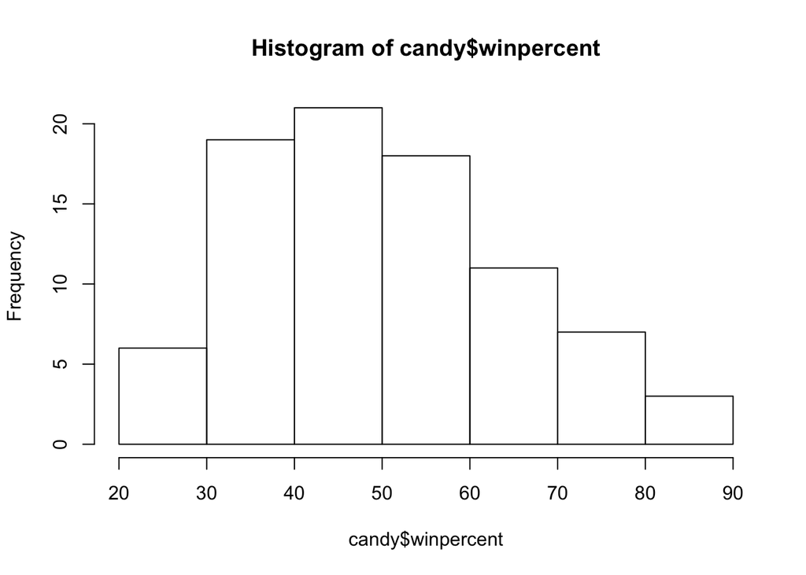

```r
hist(candy$winpercent)
```

This plot is a bit rough so let’s clean it up. We’ll start by adding an x label, title, and changing the number of bins.

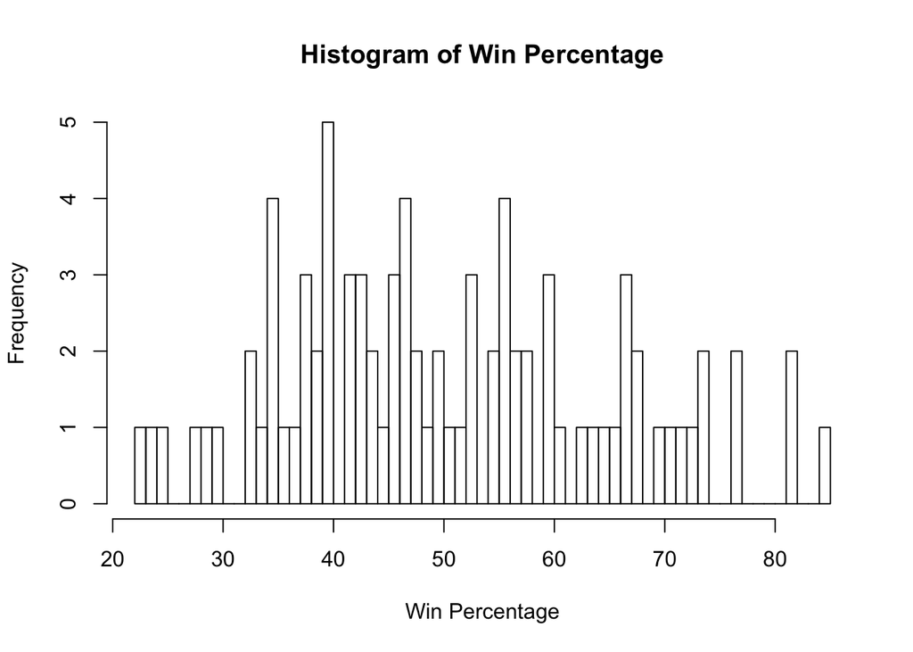

```r
hist(candy$winpercent,
     xlab = "Win Percentage",
     main = "Histogram of Win Percentage",
     breaks = 60)
```

Oops! That’s too many bins. We’ll use a smaller number in the next plot. Let’s also overlay a density plot. We can do this as follows.

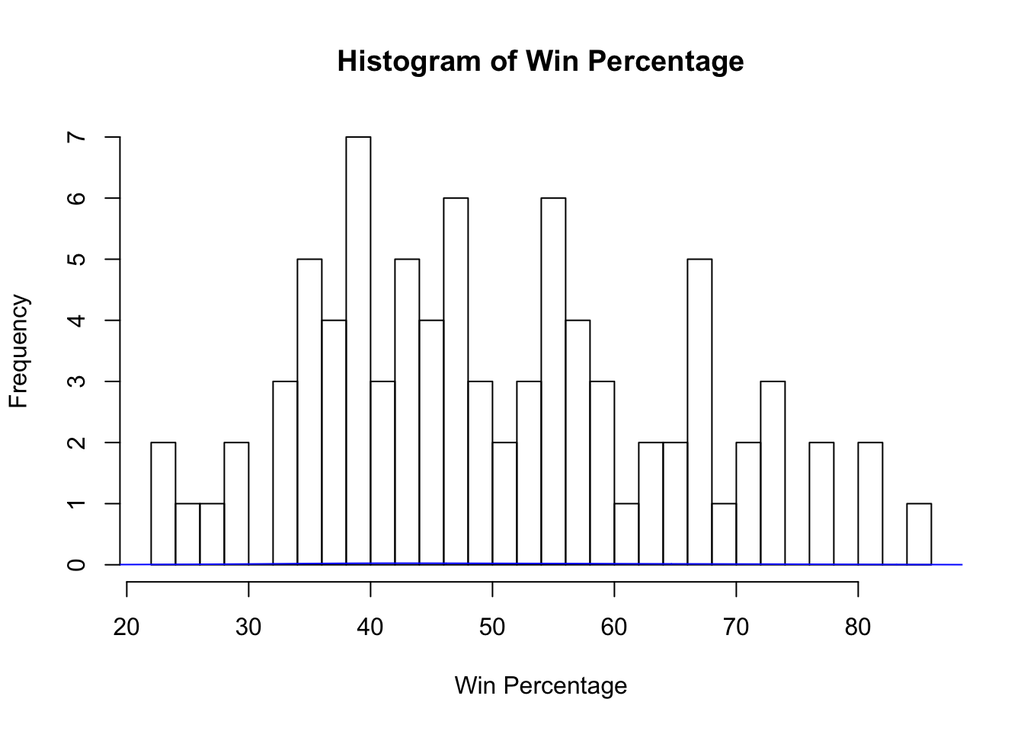

```r
hist(candy$winpercent,
     xlab = "Win Percentage",
     main = "Histogram of Win Percentage",
     breaks = 30)
win_dens <- density(candy$winpercent)
lines(win_dens, col = "blue")
```

Wait, where’s the density plot? Look at the y axis. We plotted a histogram of counts (or frequencies) but what we actually want probabilities. Let’s figure out how to do that by using the help function:

```r
?hist
# or
help(hist)
```

By default, the argument `freq` is set to `TRUE`. This means R will automatically plot a histogram of counts unless we tell it otherwise. Let’s tell it otherwise.

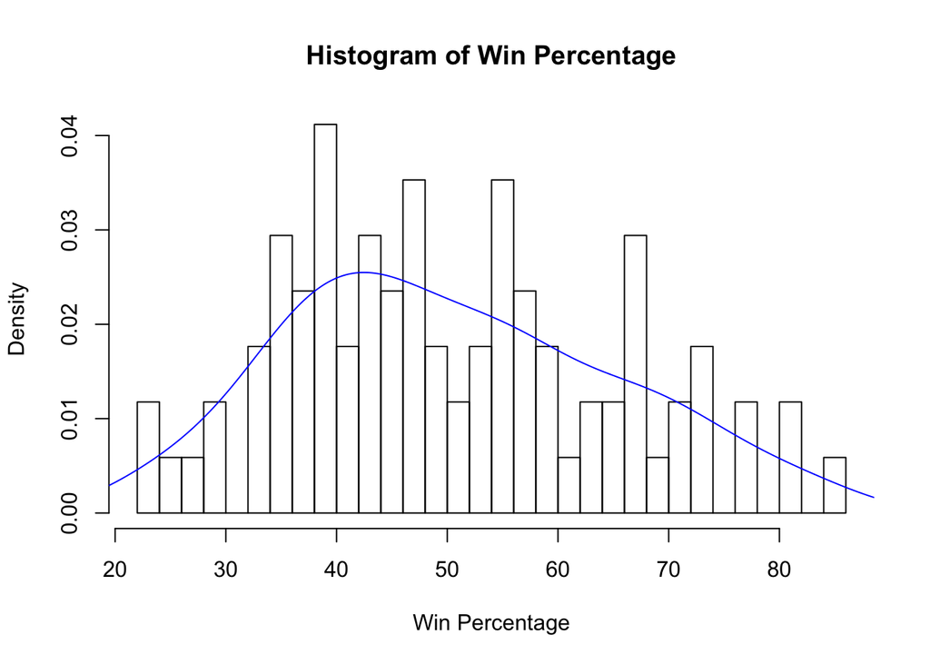

```r
hist(candy$winpercent,
     xlab = "Win Percentage",
     main = "Histogram of Win Percentage",
     breaks = 30,
     freq = FALSE)
win_dens <- density(candy$winpercent)
lines(win_dens, col = "blue")
```

Now we’ll look at how win percentage varies across some of the categorical variables.

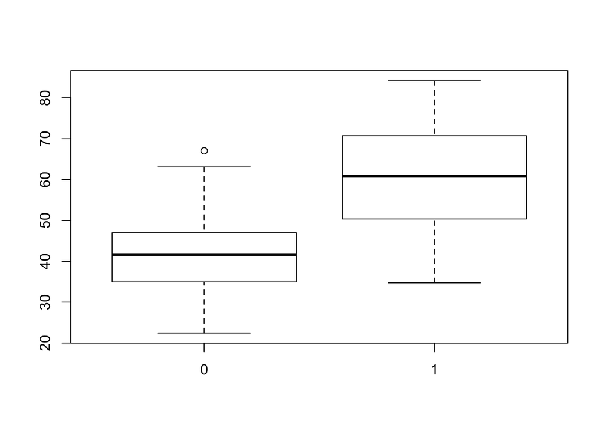

```r
boxplot(winpercent ~ chocolate,
        data = candy)
```

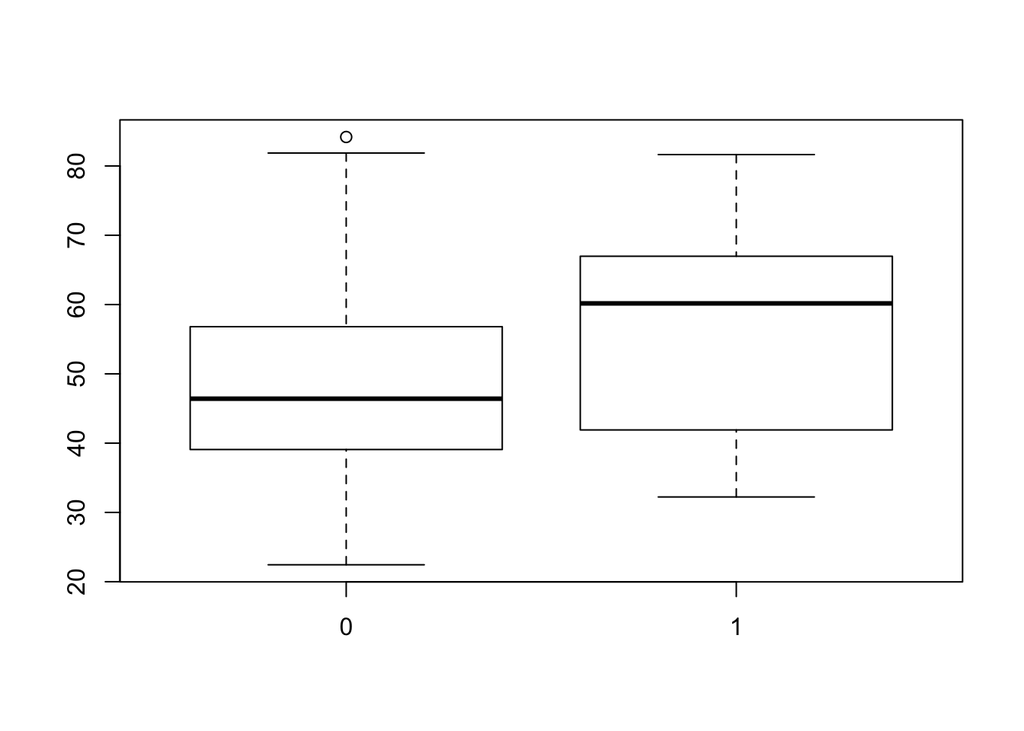

```r
boxplot(winpercent ~ caramel,
        data = candy)
```

Again, the default values `boxplot` are fine if we are just looking at the plots interactively but if we want to show someone else, we should clean them up a bit.

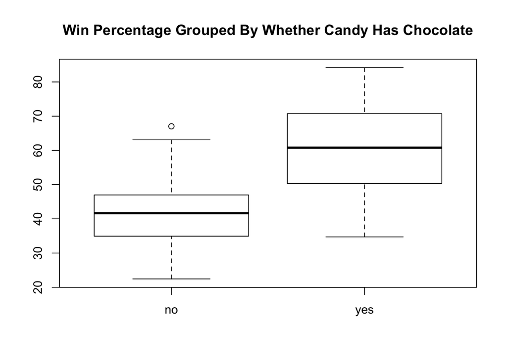

```r
boxplot(winpercent ~ chocolate,
        data = candy,
        names = c("no", "yes"),
        main = "Win Percentage Grouped By Whether Candy Has Chocolate")
```

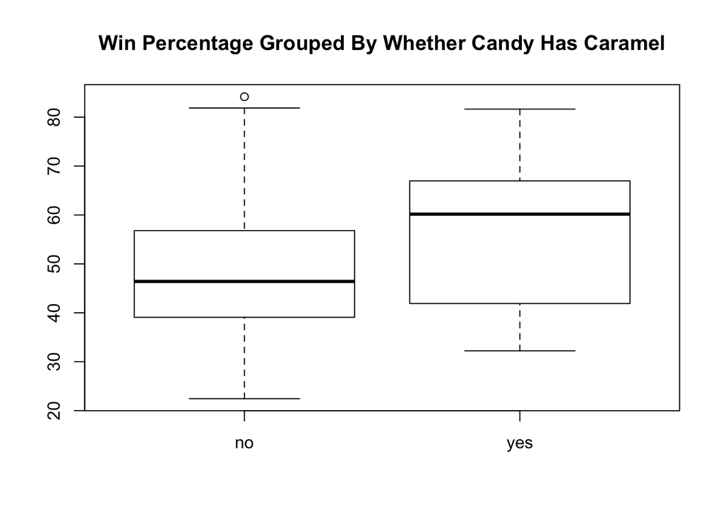

```r
boxplot(winpercent ~ caramel,
        data = candy,
        names = c("no", "yes"),
        main = "Win Percentage Grouped By Whether Candy Has Caramel")
```

These plots are better but what if we wanted to save some space and plot them side-by-side? We can use the `par` function to change some of the graphical parameters. We’ll set the `mfrow` parameter to specify that we want 1 row and 2 columns. After we make the plots, we will undo this by resetting the `mfrow` parameter.

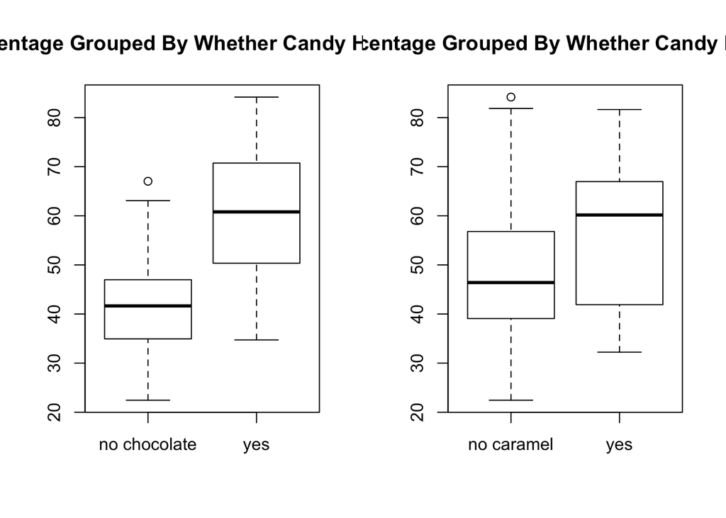

```r
par(mfrow = c(1, 2))
boxplot(winpercent ~ chocolate,
        data = candy,
        names = c("no chocolate", "yes"),
        main = "Win Percentage Grouped By Whether Candy Has Chocolate")
boxplot(winpercent ~ caramel,
        data = candy,
        names = c("no caramel", "yes"),
        main = "Win Percentage Grouped By Whether Candy Has Caramel")
```

```r
par(mfrow = c(1,1))
```

Great, now they are side-by-side and easier to compare. But the title is useless. We can fix this by changing some of the options in our code chunk. What’s a code chunk? The sections in the R Markdown file surround by the three backticks `` ``` ``. We will tell R Markdown that we want a figure caption by using `fig.cap = "your figure caption here"`[^2]. We will also specify some additional arguments to our plot function. Let’s give them some color and have the box width be proportional to the number of observations in each category.

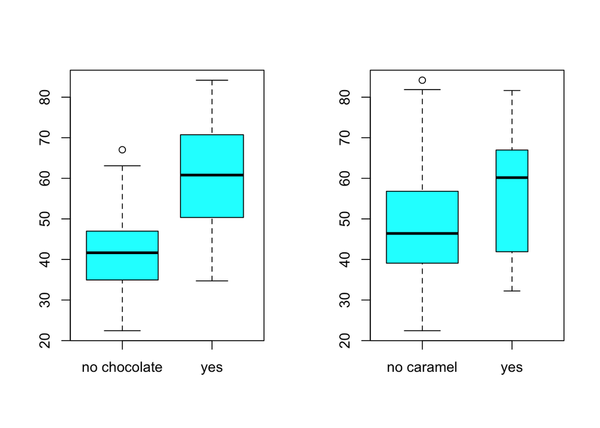

Win percentage grouped by whether the candy has chocolate or caramel.

```r
par(mfrow = c(1, 2))
boxplot(winpercent ~ chocolate,
        data = candy,
        names = c("no chocolate", "yes"),
        col = "cyan",
        varwidth = TRUE)
boxplot(winpercent ~ caramel,
        data = candy,
        names = c("no caramel", "yes"),
        col = "cyan",
        varwidth = TRUE)
```

This looks a lot better than our first go. But how did I know how to customize the plots? Do I have all the arguments memorized? Of course not! I used the help file: `?boxplot`. Generally, this is how your R sessions will go. You don’t need to memorize every function along with all it’s arguments. Eventually, you will remember a lot of the functions but you’ll still need to look up the options if the defaults aren’t cutting it. You’ll remember that to make a boxplot you use the `boxplot` function, use the default settings as a first pass, then modify the arguments to suit your needs. And you’ll probably need to use the help file to remember what all the arguments are. At first, it will probably take a while just to get something simple done. In time it gets faster and you won’t need to consult the help file for functions that you use a lot.

Let’s take an aside. What’s with the `~` in the boxplot function? R has a special syntax called a **formula** that works kind of like = in a math formula. In the chocolate boxplot, the first argument was `winpercent ~ chocolate`. This tells the `boxplot` function that we want a boxplot of win percentage vs. chocolate. Since chocolate is categorical, `boxplot` knows that we want a separate boxplot for each category. Usually, formulas are used in modeling functions. If we gave the formula `y ~ x1 + x2` to a function that fits a model, it would be the same as the math notation $y = x1 + x2$. We will see this in action shortly.

Aside over. Let’s look at one last type of plot: a scatter plot. Besides win percent, the only continuous variables are sugar and price percent. We’ll look at sugar percent. We can do this using the `plot` function. This is a generic plotting function. We’ll use it here by specifying an x and a y. We’ll put sugar percent on the x axis with win percent on the y axis.

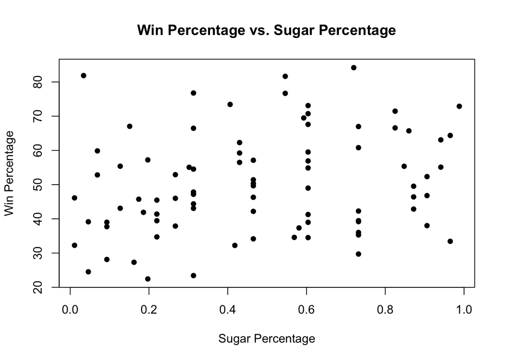

```r
plot(candy$sugarpercent, candy$winpercent,
     xlab = "Sugar Percentage",
     ylab = "Win Percentage",
     main = "Win Percentage vs. Sugar Percentage",
     pch = 16) # dots instead of circles
```

This isn’t a very informative plot, but at least now we know how to make a scatterplot. Actually, `plot` doesn’t take just an x and a y. Sometimes you can pass for example, a fitted model and plot will automatically know what plot(s) to produce based on the model type. It’s just like with the `summary` function we saw earlier. We’ll demonstrate this in action shortly.

### Fit a Model

Now that we have figured out how to make some plots, let’s fit a model. We’ll keep it simple by fitting a linear regression model. There are a TON of other models in R. A lot of times there are packages dedicated solely to fitting certain types of models or classes of models. Actually, that’s one of the reasons why R is so great.

To fit a standard regression model, we can use the function `lm` (for linear model). Just like in `boxplot`, we use a formula to specify our model. We’ll use a few categorical variables along with the continuous variables. The response (or dependent variable, or y) will be winpercent.

```r
fit <- lm(winpercent ~ chocolate +
            caramel +
            nougat +
            pluribus +
            sugarpercent +
            pricepercent,
          data = candy)
```

Then we can print the model info by typing its name.

```r
fit
```

```
##
## Call:
## lm(formula = winpercent ~ chocolate + caramel + nougat + pluribus +
##     sugarpercent + pricepercent, data = candy)
##
## Coefficients:
##  (Intercept)     chocolate       caramel        nougat      pluribus
##      39.5815       18.1716        0.5953        0.3529       -1.4274
## sugarpercent  pricepercent
##       9.1556       -2.0159
```

The ‘Call:’ portion tells us how we called the `lm` function. That is, what were all the arguments we specified. The coefficients are, well, the coefficient estimates. This is not the only information we want though. What we really want is

```r
summary(fit)
```

```
##
## Call:
## lm(formula = winpercent ~ chocolate + caramel + nougat + pluribus +
##     sugarpercent + pricepercent, data = candy)
##
## Residuals:
##      Min       1Q   Median       3Q      Max
## -23.6308  -7.8082  -0.6032   7.4015  27.9446
##
## Coefficients:
##              Estimate Std. Error t value Pr(>|t|)
## (Intercept)   39.5815     3.3460  11.829  < 2e-16 ***
## chocolate     18.1716     3.0639   5.931  7.8e-08 ***
## caramel        0.5953     3.7414   0.159   0.8740
## nougat         0.3529     5.0017   0.071   0.9439
## pluribus      -1.4274     2.7997  -0.510   0.6116
## sugarpercent   9.1556     4.8397   1.892   0.0622 .
## pricepercent  -2.0159     5.4069  -0.373   0.7103
## ---
## Signif. codes:  0 '***' 0.001 '**' 0.01 '*' 0.05 '.' 0.1 ' ' 1
##
## Residual standard error: 11.47 on 78 degrees of freedom
## Multiple R-squared:  0.4355, Adjusted R-squared:  0.392
## F-statistic: 10.03 on 6 and 78 DF,  p-value: 3.436e-08
```

See how we used the same function, `summary`, as we did with the data? This time it gives us a summary of the model. We can also use the `plot` function which gives us diagnostic plots.

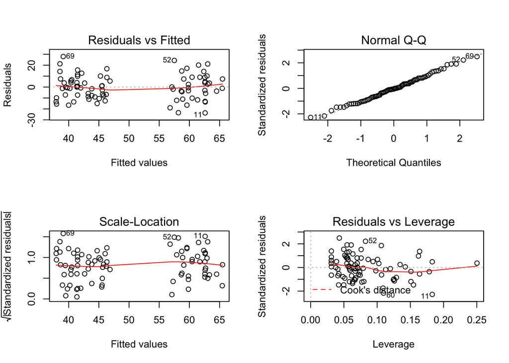

```r
par(mfrow = c(2,2))
plot(fit)
```

We might also be interested in an ANOVA table.

```r
anova(fit)
```

```
## Analysis of Variance Table
##
## Response: winpercent
##              Df  Sum Sq Mean Sq F value    Pr(>F)
## chocolate     1  7368.5  7368.5 55.9776 9.423e-11 ***
## caramel       1    57.3    57.3  0.4356   0.51121
## nougat        1    10.0    10.0  0.0762   0.78329
## pluribus      1     5.9     5.9  0.0445   0.83355
## sugarpercent  1   459.6   459.6  3.4912   0.06545 .
## pricepercent  1    18.3    18.3  0.1390   0.71028
## Residuals    78 10267.4   131.6
## ---
## Signif. codes:  0 '***' 0.001 '**' 0.01 '*' 0.05 '.' 0.1 ' ' 1
```

And we usually want confidence intervals for our coefficients.

```r
confint(fit)
```

```
##                    2.5 %    97.5 %
## (Intercept)   32.9200849 46.242848
## chocolate     12.0718725 24.271302
## caramel       -6.8531246  8.043815
## nougat        -9.6046759 10.310459
## pluribus      -7.0011880  4.146410
## sugarpercent  -0.4793982 18.790654
## pricepercent -12.7802881  8.748415
```

Lastly, we would probably want to make some predictions. To do this, we need to have a data frame that contains our new observations. We’ll just make something up.

Each of the `variable = c(blah, blah)` portions will be a column in the data frame. The names have to match the variables in our model. The `c(blah, blah)` portions use a function `c` for concatenate. We give two arguments which creates a length two vector.

```r
new_candy <- data.frame(
  chocolate = c(1,0),
  caramel = c(0,1),
  nougat = c(1,1),
  pluribus = c(1,0),
  sugarpercent = c(.75, .80),
  pricepercent = c(.70, .80)
)
new_candy
```

```
##   chocolate caramel nougat pluribus sugarpercent pricepercent
## 1         1       0      1        1         0.75          0.7
## 2         0       1      1        0         0.80          0.8
```

Now we’re ready to make predictions and prediction intervals.

```r
predict(fit,
        newdata = new_candy,
        interval = "prediction")
```

```
##        fit      lwr      upr
## 1 62.13412 36.76362 87.50462
## 2 46.24146 20.82157 71.66134
```

### The End

That’s it for this workshop. If you felt lost don’t worry. You aren’t going to understand everything right away. Hopefully we covered enough in this workshop that you can use it as starting point for your own analysis.

I recommend that you conduct your own analysis on this data set or another of your choosing. If you really want to learn R then you need to *use* R. It might be painful at first but eventually you will get the hang of it. In addition, I recommend you don’t just code the analysis but actually write it up with R Markdown. You should have an example of how to do everything you might need in the .Rmd document.

**Up next**: Data Cleaning and Manipulation With dplyr!

If you can’t wait until then, you might find these resources helpful:

- [Google](https://www.google.com)
  - This should be your go to if you have specific questions.
  - Example: “logistic regression r”
- [R for Data Science](https://r4ds.had.co.nz)
- [Data Camp](https://www.datacamp.com)
- [RStudio](https://www.rstudio.com/online-learning/)
- [Swirl](https://swirlstats.com)
[^1]: In the future, load all the packages your analysis depends on at the beginning of your code. This makes it easier for other people to run your analysis
[^2]: For more ways to customize see the [knitr chunk options](https://yihui.name/knitr/options/). The `knitr` R package handles the back end of the .Rmd conversion.